# Study Area

The assessment of potential tourist-vessel collision risk for cetaceans was conducted within the Colombian EEZ. The study area includes the Caribbean basin (69°30’W–82°10’W and 8°39’N–16°10’N) with a total area of 589,302 km<sup>2</sup>, and the Pacific basin (77°54’W–85°49’W and 1°22’N–7°10’N) with 332,129 km<sup>2</sup> of total area (Figure 1).

The Colombian Caribbean is considered oligotrophic, excepting in some coastal regions, such as Puerto Bolivar (La Guajira department) and Santa Marta (Magdalena department), where seasonal upwelling events that increase productivity in coastal areas allow occurrence of top predators such as cetaceans (Gordon 1967; Fajardo 1979; Andrade et al. 2003; Andrade and Barton 2005; Criales Hernández et al. 2006; Lonin et al. 2010; Paramo et al. 2011; Rueda-Roa and Muller-Karger 2013; Gutiérrez et al. 2015; Farías-Curtidor et al. 2017; Barragán-Barrera et al. 2019). Conversely, the Colombian Pacific is influenced by coastal upwelling events thoroughly year, especially on February-April and November-December months (Villegas 1997, 2003; Díaz and Gusmao 2008) maintaining high productivity in coastal areas, especially in the Gorgona Island National Natural Park (NNP) (Pineda 1995).

Both Caribbean and Pacific areas are influenced by tourism-vessel activities in Colombia; however, the main tourist purposes are different for each region. In the Caribbean, water tourism has been focused mainly on cruise ships and diving activities while in the Pacific tourist vessel traffic is principally for nature activities such as diving and whale-watching onboard pleasure vessels and small boats, respectively (Aguilera-Díaz et al. 2006; Sánchez and Jaramillo-Hurtado 2010; Brida et al. 2012; Trujillo and Ávila 2013 ). These differences are based on tourist infrastructure, which is highly developed in the Colombian Caribbean in contrast to the Pacific region. Along the 1,600 km of the Colombian Caribbean coastline are located tourist cities such as Cartagena de Indias, which has a greater hotel development (Aguilera-Díaz et al. 2006; Sánchez-Fernández et al. 2010; Brida et al. 2012). Conversely, the Pacific holds more pristine areas, being the ecotourism and the whale-watching activities predominant, because the Colombian Pacific is highly biodiverse and is part of the breeding zone for stock G humpback whales (Flórez-González et al. 2007; Sánchez and Jaramillo-Hurtado 2010; Aguayo Lobo et al. 2011; Trujillo and Ávila 2013; Acevedo et al. 2017; Fagua and Ramsey 2019).

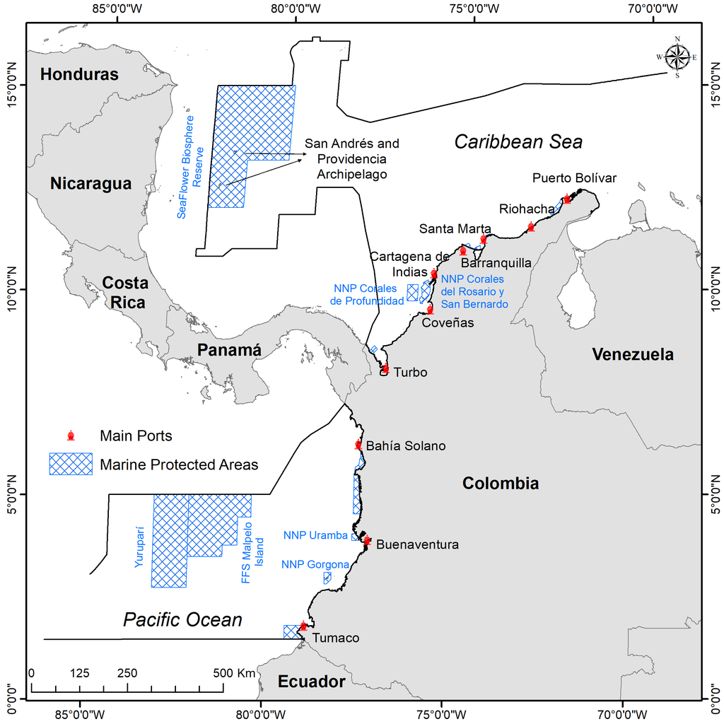

Figure 1. Study area with the location of marine protected areas and main ports in the Colombian Exclusive Economic Zone (EEZ).

# REFERENCES

Acevedo J, Aguayo-Lobo A, Allen J, et al (2017) Migratory preferences of humpback whales between feeding and breeding grounds in the eastern South Pacific. Marine Mammal Science 33:1035–1052. https://doi.org/10.1111/mms.12423

Aguayo Lobo A, Acevedo J, Cornejo S (2011) La ballena jorobada Conservación en el Parque Marino Francisco Coloane. Ocho Libros Editores., Santiago de Chile

Aguilera-Díaz MM, Bernal-Mattos C, Quintero-Puentes P (2006) Turismo y desarrollo en el Caribe colombiano. Documentos de Trabajo Sobre Economía Regional y Urbana; No 79

Andrade CA, Barton ED (2005) The Guajira upwelling system. Continental Shelf Research 25:1003–1022. https://doi.org/10.1016/j.csr.2004.12.012

Andrade CA, Barton ED, Mooers CNK (2003) Evidence for an eastward flow along the Central and South American Caribbean Coast. Journal of Geophysical Research: Oceans 108:

Barragán-Barrera DC, Luna-Acosta A, May-Collado LJ, et al (2019) Foraging habits and levels of mercury in a resident population of bottlenose dolphins (*Tursiops truncatus*) in Bocas del Toro Archipelago, Caribbean Sea, Panama. Marine pollution bulletin 145:343–356. https://doi.org/doi.org/10.1016/j.marpolbul.2019.04.076

Brida JG, Pulina M, Riaño E, Zapata-Aguirre S (2012) Cruise passengers’ experience embarking in a Caribbean home port. The case study of Cartagena de Indias. Ocean and Coastal Management 55:135–145. https://doi.org/10.1016/j.ocecoaman.2011.10.003

Criales Hernández MI, B. García C, Wolff M (2006) Flujos de biomasa y estructura de un ecosistema de surgencia tropical en La Guajira, Caribe colombiano. Revista de Biología Tropical 54: https://doi.org/10.15517/rbt.v54i4.3103

Díaz X, Gusmao LM de O (2008) Influencia de los eventos climáticos El Niño y La Niña en la comunidad de Chaetognatha de las aguas superficiales del océano pacífico Colombiano. Revista Brasileira de Engenharia de Pesca 3:30–50

Fagua JC, Ramsey RD (2019) Geospatial modeling of land cover change in the Chocó-Darien global ecoregion of South America; One of most biodiverse and rainy areas in the world. PloS one 14:e0211324

Fajardo GE (1979) Surgencia costera en las proximidades de la península colombiana de la Guajira. Boletín Científico CIOH 7–19. https://doi.org/10.26640/22159045.6

Farías-Curtidor N, Barragán-Barrera DC, Chávez-Carreño PA, et al (2017) Range extension for the common dolphin (*Delphinus* sp.) to the Colombian Caribbean, with taxonomic implications from genetic barcoding analysis. PLoS ONE 12:

Flórez-González L, Ávila IC, Capella JJ, et al (2007) Estrategia para la conservación de la Ballena Jorobada del Pacífico Sudeste. Lineamientos para un Plan de Acción Regional e Iniciativas Nacionales. Fundación Yubarta, Cali

Gordon AL (1967) Circulation of the Caribbean Sea. J Geophys Res 72:6207–6223

Gutiérrez GA, Correa MA, Hormazabal SE (2015) Análisis de la variabilidad espacio-temporal del sistema de surgencia de La Guajira en el dominio espacio-frecuencia, empleando el MTM-SVD (Multi Taper Method Singular Value Decomposition). Bol Cient CIOH 33:87–106

Lonin SA, Hernández JL, Palacios DM (2010) Atmospheric events disrupting coastal upwelling in the southwestern Caribbean. Journal of Geophysical Research: Oceans 115:

Paramo J, Correa M, Núñez S (2011) Evidencias de desacople físico-biológico en el sistema de surgencia en La Guajira, Caribe colombiano. Rev Biol Mar Oceanogr 46:421–430

Pineda AR (1995) Condiciones hidrológicas en la cuenca del Pacífico colombiano. Bol Cient CCCP 73–97

Rueda-Roa DT, Muller-Karger FE (2013) The southern Caribbean upwelling system: Sea surface temperature, wind forcing and chlorophyll concentration patterns. Deep Sea Research Part I: Oceanographic Research Papers 78:102–114

Sánchez CI, Jaramillo-Hurtado ME (2010) Policies for enhancing sustainability and competitiveness in tourism in Colombia. Worldwide Hospitality and Tourism Themes

Sánchez-Fernández D, Lobo JM, Hernández-Manrique OL (2010) Species distribution models that do not incorporate global data misrepresent potential distributions: a case study using Iberian diving beetles. Diversity and Distributions no–no. https://doi.org/10.1111/j.1472-4642.2010.00716.x

Trujillo F, Ávila IC (2013) “Uso no letal de cetáceos: el turismo de observación de delfines y ballenas como estrategia de conservación en Colombia,”. In: F. A. Trujillo DC A. Gärtner, Diazgranados MC (eds) Diagnóstico del estado de conocimiento y conservación de los mamíferos acuáticos en Colombia. Ministerio de Ambiente y Desarrollo Sostenible / Fundación Omacha / Conservación Internacional / WWF, Bogotá D. C. Colombia., pp 232–251

Villegas NL (1997) Estudio del movimiento vertical de las aguas en la región Este de la Cuenca del Pacífico colombiano. Bol Cient CCCP 6:71–80

Villegas NL (2003) Evolución mensual de las corrientes verticales y zonas de surgencia en la Cuenca del Pacífico colombiano CPC. Bol Cient CCCP 9:34–44